# Stats on VUS data bases

Andrey Ziyatdinov

2017-04-19

# 1 ClinVar

https://www.ncbi.nlm.nih.gov/clinvar/

> ClinVar is a freely accessible, public archive of reports of the relationships among human variations and phenotypes, with supporting evidence. ClinVar thus facilitates access to and communication about the relationships asserted between human variation and observed health status, and the history of that interpretation.

> A major goal is to support computational (re)evaluation, both of genotypes and assertions, and to enable the ongoing evolution and development of knowledge regarding variations and associated phenotypes.

## 1.1 Get data

We searched for all variants of 7 breast/ovarian cancer genes mentioned in the grant proposal.

The fetched data table included:

- 2661 variants (rows) for 23 genes
- 5 variables (columns) of interest such as gene and clinical significance.

First 10 raws of the table:

```
# A tibble: 2,661 × 5
      uid gene_sort chr_sort location_sort  clinical_significance
    <chr>     <chr>    <chr>         <int>                  <chr>
1  412448      BAP1       03      52403223 Uncertain significance
2  412446      BAP1       03      52403703 Uncertain significance
3  412442      BAP1       03      52403593 Uncertain significance
4  412441      BAP1       03      52403815 Uncertain significance
5  412439      BAP1       03      52403208 Uncertain significance
6  412437      BAP1       03      52407431 Uncertain significance
7  412436      BAP1       03      52408545 Uncertain significance
8  412432      BAP1       03      52404487 Uncertain significance
9  412427      BAP1       03      52404491 Uncertain significance
10 412424      BAP1       03      52404486 Uncertain significance
# ... with 2,651 more rows
```

## 1.2 Stats on genes

| gene_sort | n_all | n_benign | n_pathogenic | n_uncertain_significance | n_conflicting_pathogenicity |
| --- | --- | --- | --- | --- | --- |
| BRCA2 | 964 | 613 | 9 | 218 | 113 |
| BRCA1 | 747 | 590 | 18 | 84 | 50 |
| ATM | 391 | 0 | 4 | 340 | 33 |
| PALB2 | 150 | 0 | 1 | 124 | 18 |
| BRIP1 | 140 | 0 | 5 | 121 | 8 |
| CHEK2 | 122 | 0 | 1 | 92 | 16 |
| BARD1 | 101 | 0 | 0 | 90 | 10 |
| BAP1 | 27 | 0 | 1 | 25 | 1 |
| CDH1 | 2 | 0 | 0 | 2 | 0 |
| MSH2 | 2 | 0 | 0 | 1 | 1 |

# 2 BRCA1 CIRCOS

- Breast Cancer Information Core https://research.nhgri.nih.gov/bic/
  - Cancer Susceptibility http://healthcare.utah.edu/huntsmancancerinstitute/research/cancer-genetics/cancer-susceptibility/#a
    - BRCA1 CIRCOS: A compilation of functional data https://research.nhgri.nih.gov/projects/bic/circos/index.shtml

> The BRCA1 Circos is a visualization resource that compiles and displays functional data on all documented BRCA1 missense variants. This resource provides an interactive display of data from published BRCA1 functional studies that will aid researchers in interpreting the functional consequences of BRCA1 variants.

https://research.nhgri.nih.gov/projects/bic/circos/download.shtml

One can download the complete BRCA1 Circos dataset (679 entries) in tab-delimited text format.

## 2.1 Get data

We selected a small subset of variables due to many missing entries accross the variables. Description of the variables is on [BRCA1 Circos - Track Descriptions](https://research.nhgri.nih.gov/projects/bic/circos/trackdescriptions/index.shtml)

Predictors:

- Track 1 - Exon number: Numbers for all translated BRCA1 exons.
- Track 2 - BIC entries: Breast Cancer Information Core (BIC) maintains a database of documented BRCA1 and BRCA2 variants.
- Track 5 – Bayes factor (Iversen et al. 2011): The Bayes factor is equivalent to the posterior odds that variant is protein damaging based on transcriptional assays.
  - This track allows one to interpret the degree to which the data in Track 4 (not used in our anaylsis) support the hypothesis (i.e. that a variant is protein damaging).

Response:

- Track 3 – IARC Class (Plon et al. 2008): In 2008, the International Agency for Research on Cancer (IARC) proposed a five-class system based on degree of likelihood of pathogenicity derived from multifactorial models.
  - The five classes are Class 1 (not pathogenic or of no clinical significance), Class 2 (likely not pathogenic or of little clinical significance), Class 3 (uncertain), Class 4 (likely pathogenic), and Class 5 (definitely pathogenic).

First 10 raws of the table with complete observations:

```
# A tibble: 29 × 5
   dbsnp_id_from_ncbi iarc_class exon_number bic_entries bayes_factor
                <chr>      <int>       <chr>       <int>        <dbl>
1          rs80357365          1      exon13           3        -5.73
2          rs41293455          1      exon13          15        -3.78
3          rs80357389          1      exon14          26        -6.24
4           rs1800744          1      exon15          58        -6.62
5          rs55815649          1      exon15          26        -6.81
6          rs28897691          1      exon15          31        -6.51
7          rs56119278          1      exon16          12        -5.14
8           rs1799966          1      exon16         248        -7.03
9          rs70953660          1      exon16          14        -6.82
10          rs4986854          1      exon16          96        -5.77
# ... with 19 more rows
```

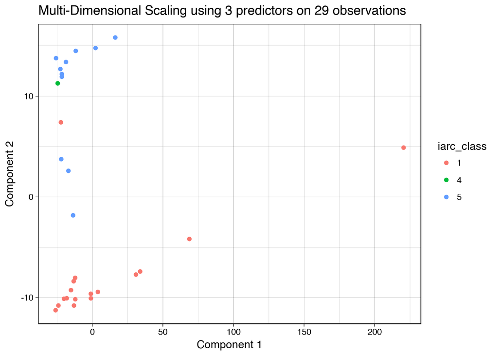